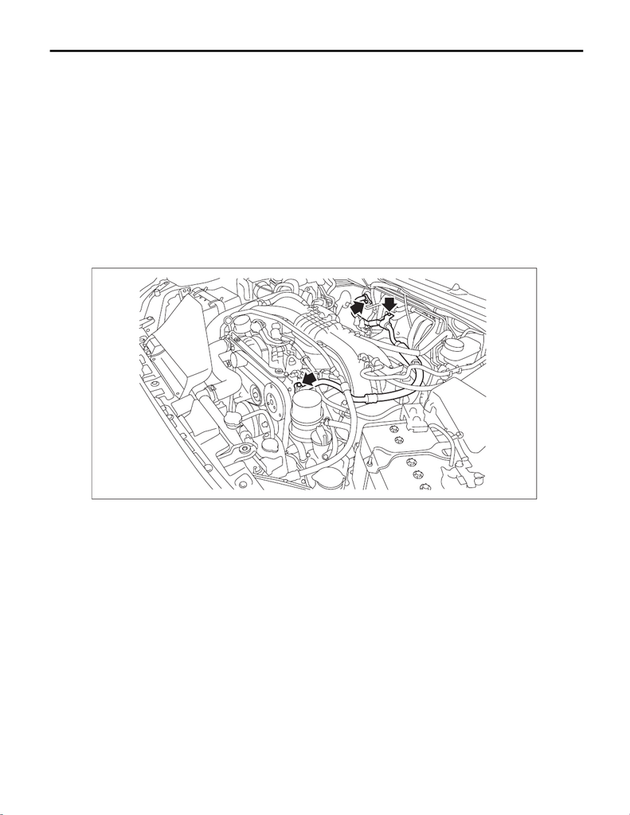

AC-63

Hose and Pipe

HVAC SYSTEM (HEATER, VENTILATOR AND A/C)

19.Hose and Pipe

A: REMOVAL

1. LOW-PRESSURE HOSE

1) Using the refrigerant recovery system, discharge refrigerant. <Ref. to AC-26, PROCEDURE, Refrigerant

Recovery Procedure.>

2) Remove the intercooler.

• Except for STI model: <Ref. to IN(w/o STI)-38, REMOVAL, Intercooler.>

• STI model: <Ref. to IN(STI)-13, REMOVAL, Intercooler.>

3) Remove the bolts and detach the hose - pressure discharge on the compressor side. (STI model)

4) Remove the bolts and remove the hose - pressure suction.

CAUTION:

• Do not apply excessive force to the hose.

• Seal the disconnected hose, compressor and engaging part of expansion valve with a plug or vinyl

tape to prevent foreign matter from entering.

2. HIGH-PRESSURE HOSE

1) Using the refrigerant recovery system, discharge refrigerant. <Ref. to AC-26, PROCEDURE, Refrigerant

Recovery Procedure.>

2) Remove the reservoir tank.

• Except for STI model: <Ref. to CO(w/o STI)-52, REMOVAL, Reservoir Tank.>

• STI model: <Ref. to CO(STI)-27, REMOVAL, Reservoir Tank.>

3) Lift up the vehicle.

4) Remove the under cover - front. <Ref. to EI-21, REMOVAL, Front Under Cover.>

AC-03539

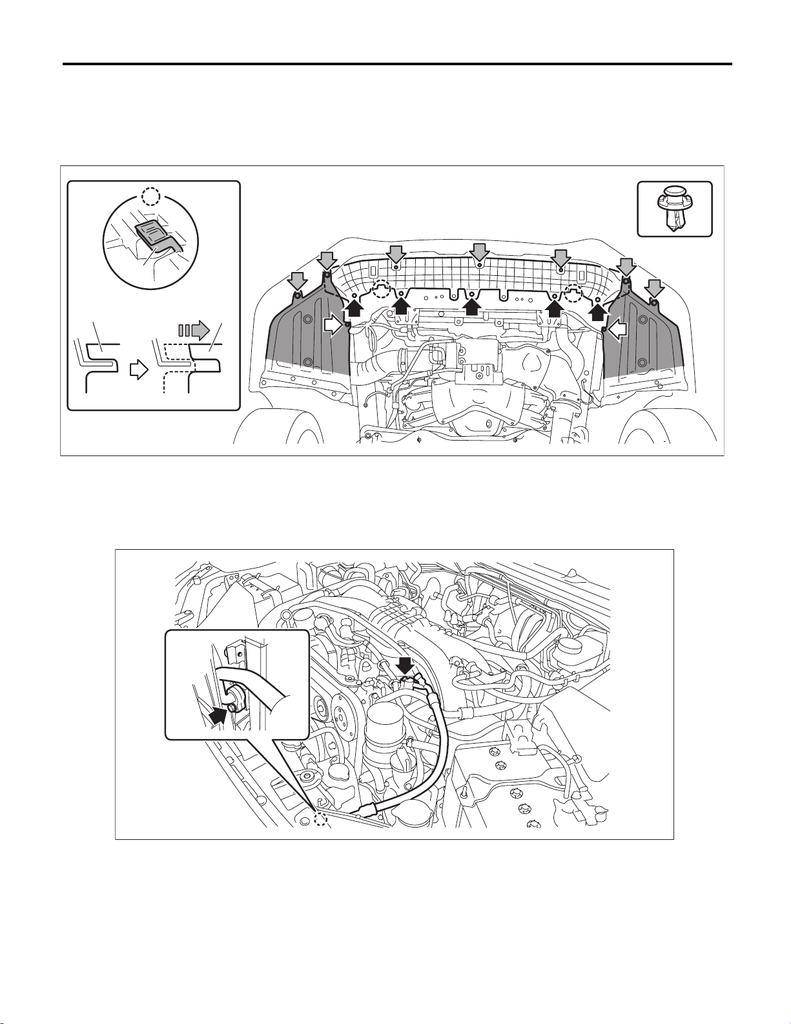

AC-64

Hose and Pipe

HVAC SYSTEM (HEATER, VENTILATOR AND A/C)

5) Remove the bracket – front center LWR.

(1) Remove the screw and clips, and turn over the mud guard - front.

(2) Remove the bolts and clips, and remove the bracket – front center LWR.

NOTE:

While entirely pushing the bracket – front center LWR forward, remove the two hooks (a) on the left and right.

6) Remove the bolts and remove the hose - pressure discharge.

CAUTION:

• Do not apply excessive force to the hose.

• Seal the disconnected hose, compressor and engaging part of compressor with a plug or vinyl

tape to prevent foreign matter from entering.

AC-03585

(a)

(a)

(a)

AC-03540

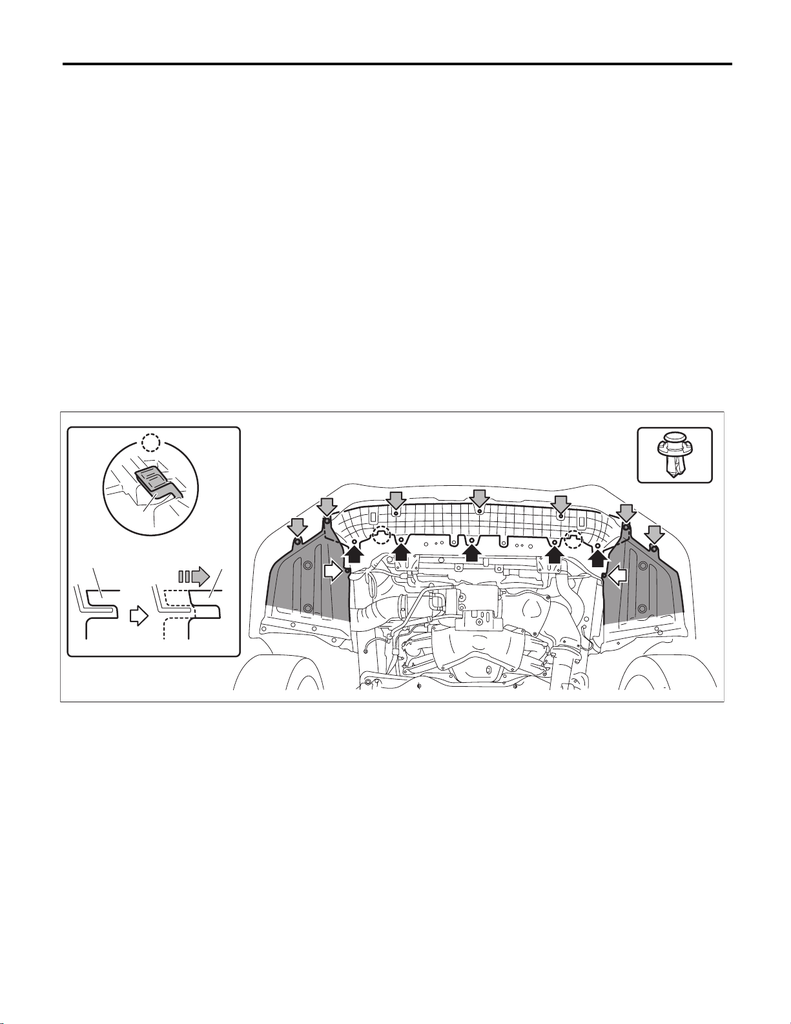

AC-65

Hose and Pipe

HVAC SYSTEM (HEATER, VENTILATOR AND A/C)

3. A/C PIPE

1) Using the refrigerant recovery system, discharge refrigerant. <Ref. to AC-26, PROCEDURE, Refrigerant

Recovery Procedure.>

2) Remove the battery.

• Except for STI model: <Ref. to SC(w/o STI)-50, REMOVAL, Battery.>

• STI model: <Ref. to SC(STI)-21, REMOVAL, Battery.>

3) Remove the intercooler.

• Except for STI model: <Ref. to IN(w/o STI)-38, REMOVAL, Intercooler.>

• STI model: <Ref. to IN(STI)-13, REMOVAL, Intercooler.>

4) Remove the secondary air pump. (STI model) <Ref. to EC(STI)-53, REMOVAL, Secondary Air Pump.>

5) Remove the reservoir tank.

• Except for STI model: <Ref. to CO(w/o STI)-52, REMOVAL, Reservoir Tank.>

• STI model: <Ref. to CO(STI)-27, REMOVAL, Reservoir Tank.>

6) Lift up the vehicle.

7) Remove the under cover - front. <Ref. to EI-21, REMOVAL, Front Under Cover.>

8) Remove the bracket – front center LWR.

(1) Remove the screw and clips, and turn over the mud guard - front.

(2) Remove the bolts and clips, and remove the bracket – front center LWR.

NOTE:

While entirely pushing the bracket – front center LWR forward, remove the two hooks (a) on the left and right.

AC-03585

(a)

(a)

(a)

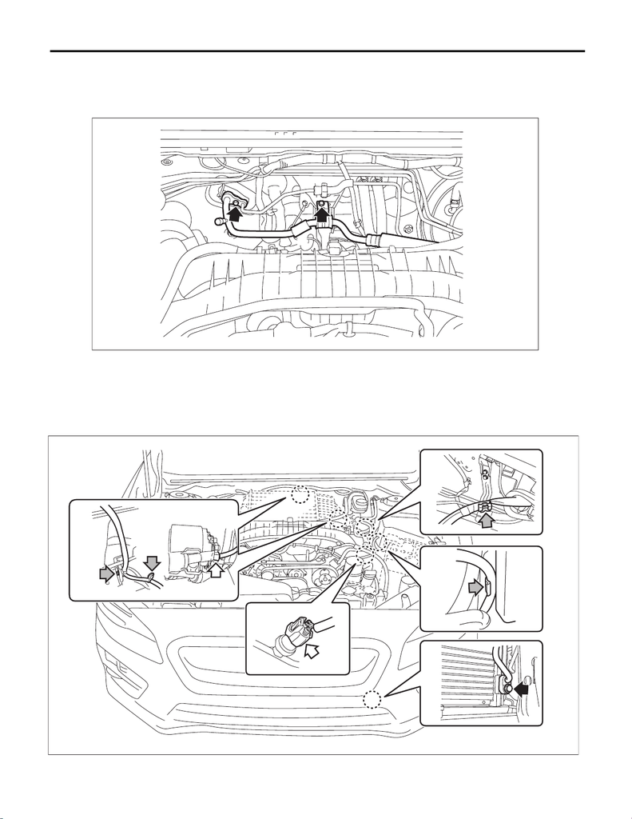

AC-66

Hose and Pipe

HVAC SYSTEM (HEATER, VENTILATOR AND A/C)

9) Remove the bolts and detach the hose - pressure suction.

CAUTION:

Seal the disconnected hose and engaging part of expansion valve with a plug or vinyl tape to prevent

foreign matter from entering.

10) Remove the pipe - evaporator cooling.

(1) Release the lock and remove the cable clamp.

(2) Release the harness clip, and disconnect the starter connector.

(3) Disconnect the battery sensor harness from the main fuse box. (Except for STI model)

(4) Disconnect the pressure switch connector.

(5) Remove the bolt, and detach the pipe - evaporator cooling.

AC-03543

AC-03541

(5)

(3)

(1)

(4)

(2)

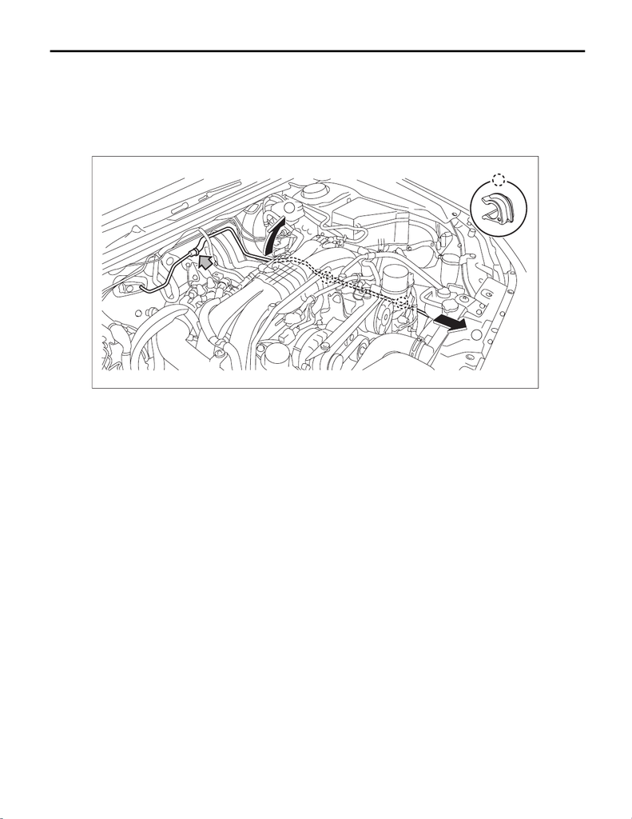

AC-67

Hose and Pipe

HVAC SYSTEM (HEATER, VENTILATOR AND A/C)

(6) Remove the clip - pipe and the clip, and remove the pipe - evaporator cooling in numerical order as

shown in the figure.

CAUTION:

• Do not apply excessive force to the pipe.

• Seal the disconnected pipe, expansion valve and engaging part of condenser with a plug or vinyl

tape to prevent foreign matter from entering.

• Do not pull the harness and cable forcibly.

B: INSTALLATION

1. LOW-PRESSURE HOSE

CAUTION:

• If the hose has been replaced, add an appropriate amount of compressor oil to the compressor.

<Ref. to AC-34, ADJUSTMENT, Compressor Oil.>

• Replace the O-rings with new parts, and then apply compressor oil.

• When connecting hoses, do not apply an excessive force to them. After installing, check that no

torsion or excessive tension applied to the hoses.

1) Install the hose - pressure suction.

Tightening torque:

Air conditioning unit: <Ref. to AC-9, AIR CONDITIONING UNIT, COMPONENT, General Descrip-

tion.>

2) Install the hose - pressure suction discharge. (STI model)

Tightening torque:

10 N·m (1.0 kgf-m, 7.4 ft-lb)

3) Install the intercooler.

• Except for STI model: <Ref. to IN(w/o STI)-41, INSTALLATION, Intercooler.>

• STI model: <Ref. to IN(STI)-14, INSTALLATION, Intercooler.>

4) Charge refrigerant. <Ref. to AC-27, PROCEDURE, Refrigerant Charging Procedure.>

AC-03542

1

2

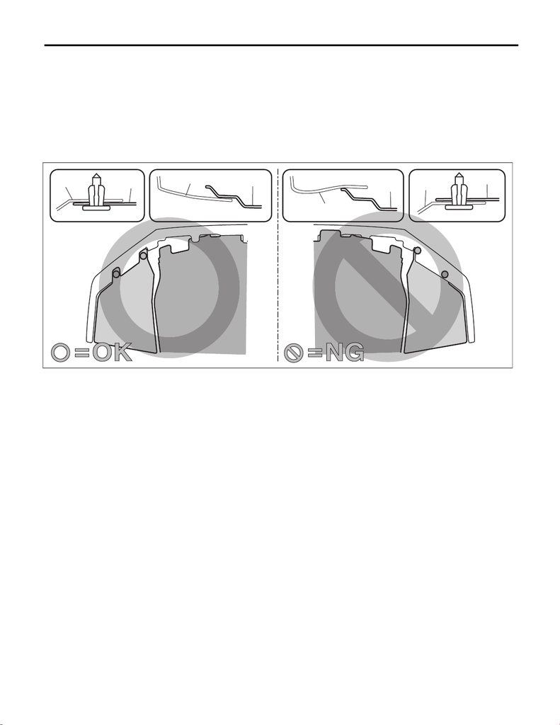

AC-68

Hose and Pipe

HVAC SYSTEM (HEATER, VENTILATOR AND A/C)

2. HIGH-PRESSURE HOSE

CAUTION:

• If the hose has been replaced, add an appropriate amount of compressor oil to the compressor.

<Ref. to AC-34, ADJUSTMENT, Compressor Oil.>

• Replace the O-rings with new parts, and then apply compressor oil.

• When connecting hoses, do not apply an excessive force to them. After installing, check that no

torsion or excessive tension applied to the hoses.

• Install so that the front end of the under cover (b) comes inside the bumper face - front (a), and the

front end of the mud guard (c) comes outside the bumper face - front (a).

1) Install the hose - pressure suction discharge.

Tightening torque:

Air conditioning unit: <Ref. to AC-9, AIR CONDITIONING UNIT, COMPONENT, General Descrip-

tion.>

2) Install the bracket - front center LWR.

Tightening torque:

7.5 N·m (0.8 kgf-m, 5.5 ft-lb)

3) Install the under cover - front.

Tightening torque:

7.5 N·m (0.8 kgf-m, 5.5 ft-lb)

4) Lower the vehicle.

5) Install the reservoir tank.

• Except for STI model: <Ref. to CO(w/o STI)-52, INSTALLATION, Reservoir Tank.>

• STI model: <Ref. to CO(STI)-27, INSTALLATION, Reservoir Tank.>

6) Charge refrigerant. <Ref. to AC-27, PROCEDURE, Refrigerant Charging Procedure.>

COM00138

(a)

(c)

(b)

(a)

(a)

(c)

(b)

(a)

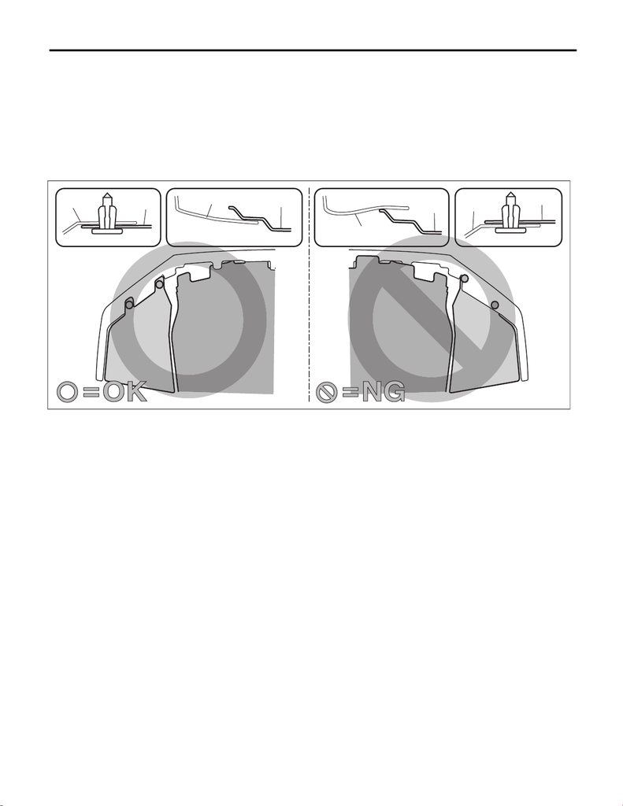

AC-69

Hose and Pipe

HVAC SYSTEM (HEATER, VENTILATOR AND A/C)

3. A/C PIPE

CAUTION:

• If the hose and pipe have been replaced, add an appropriate amount of compressor oil to the com-

pressor. <Ref. to AC-34, ADJUSTMENT, Compressor Oil.>

• Replace the O-rings with new parts, and then apply compressor oil.

• When connecting hoses and pipes, do not apply excessive force. After installing, check that no tor-

sion or excessive tension applied to the hoses.

• Install so that the front end of the under cover (b) comes inside the bumper face - front (a), and the

front end of the mud guard (c) comes outside the bumper face - front (a).

1) Install the pipe - evaporator cooling.

Tightening torque:

7.5 N·m (0.8 kgf-m, 5.5 ft-lb)

2) Install the hose - pressure suction.

Tightening torque:

7.5 N·m (0.8 kgf-m, 5.5 ft-lb)

3) Install the bracket - front center LWR.

Tightening torque:

7.5 N·m (0.8 kgf-m, 5.5 ft-lb)

4) Install the under cover - front.

5) Lower the vehicle.

6) Install the reservoir tank.

• Except for STI model: <Ref. to CO(w/o STI)-52, INSTALLATION, Reservoir Tank.>

• STI model: <Ref. to CO(STI)-27, INSTALLATION, Reservoir Tank.>

7) Install the secondary air pump. (STI model) <Ref. to EC(STI)-53, INSTALLATION, Secondary Air Pump.>

8) Install the intercooler.

• Except for STI model: <Ref. to IN(w/o STI)-41, INSTALLATION, Intercooler.>

• STI model: <Ref. to IN(STI)-14, INSTALLATION, Intercooler.>

9) Install the battery.

• Except for STI model: <Ref. to SC(w/o STI)-50, INSTALLATION, Battery.>

• STI model: <Ref. to SC(STI)-21, INSTALLATION, Battery.>

10) Charge refrigerant. <Ref. to AC-27, PROCEDURE, Refrigerant Charging Procedure.>

COM00138

(a)

(c)

(b)

(a)

(a)

(c)

(b)

(a)

[figure not shown]

AC-70

Hose and Pipe

HVAC SYSTEM (HEATER, VENTILATOR AND A/C)

C: INSPECTION

1) Check the hoses for cracks, damage and expansion. Replace the hose if faulty.

2) Check the pipes for crack or damage. Replace the pipe if faulty.